# 京津冀地区废水排放量影响因素的结构分解分析

2017年3月10日

## 引言

京津冀地区作为我国经济发展的核心区域，战略地位非常重要。但近些年，随着城镇人口的增长、产业规模的扩大、城市化水平的提升，该地区面临着严重的水质危机，水污染问题已严重威胁地区居民健康和生活质量，并制约社会经济发展。2015年4月国务院发布的《水污染防治行动计划》(国发(2015)H号文)明确提出“到2020年京津冀区域丧失使用功能（劣于Ｖ类）的水体断面比例下降15％左右”。鉴于京津冀地区经济社会发展和废水排放现状，对影响该地区废水排放量的各因素作进一步深入的研究与分析，不仅对该地区调整产业结构实现经济的可持续发展有重要的理论和现实意义，而且有利于解决与水相关的资源环境问题和规划水资源发展战略。

鉴于此，本章在2007年和2012年京津冀地区投入产出表的基础上，运用结构分解分析方法对2007-2012年期间京津冀地区废水排法总量变动的影响因素进行分析研究。首先将影响因素分解为用水强度、技术水平、最终需求结构、最终需求总量结构、人口总数和人均GDP；其次在最终需求层面对废水排放总量变动的影响因素进行了进一步分解。

## 模型

为了研究人口增长、生活水平提高、技术进步等因素对环境的影响，Ehrlich等提出了传统的\(IPAT\)模型，该模型可以表示为如下的形式： \[Impact=Population*Affluence*Technology\] 其中\(I(Impact)\)表示环境影响或资源消耗，\(P(Population)\)表示人口总数， \(A(Affluence)\)表示经济发展或社会富裕程度，\(T(Technology)\)表示技术水平。

上式可以扩展为基于投入产出表的形式。对于废水排放量，\(IPAT\)模型可表示为： \[Waste=PW*L*S*V*p*g\] 为了进一步分析影响废水排放总量变化的驱动因素，我们利用结构分解模型对废水排放总量变动进行分解。废水排放总量的变化表示为：

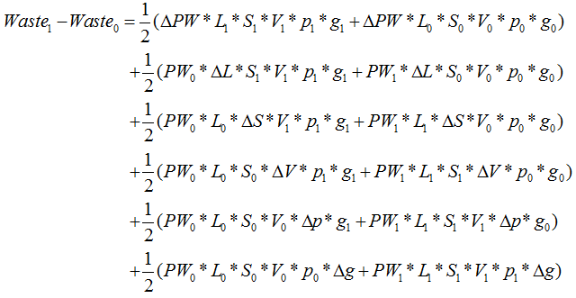

## 废水排放量影响因素分解

我们利用2007和2012年北京、天津和河北省40部门水资源投入产出表，其中最终需求部分包括最终消费支出（居民消费支出和政府消费支出）、资本形成总额（固定资本形成总额和存货增加）、流出（出口和调出）和流入（进口和调入），研究北京、天津和河北省2007年到2012年间废水排放总量增加的主要驱动因素。

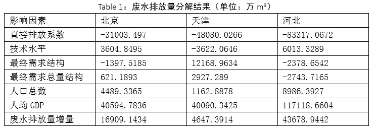

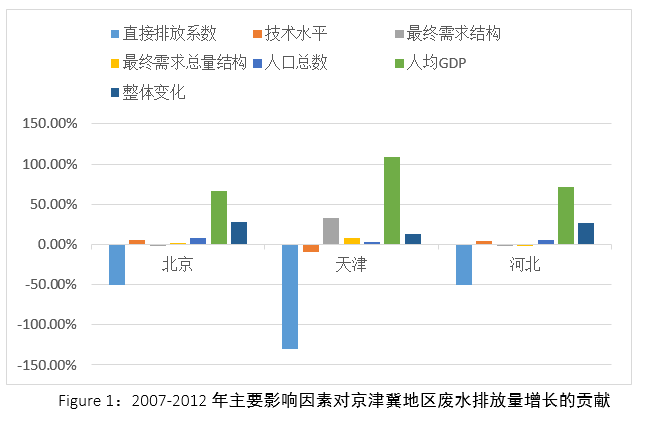

## 最终使用对废水排放量的影响

我们还可以从最终使用的角度来进一步分解京津冀地区废水排放量增长的驱动因素。将废水排放总量表示成如下的形式： \[Waste=PW*L*f=PW*L*(f_c+f_g+f_e+f_i)\] 其中\(Waste\)为废水排放总量；\(PW\)为直接排放系数，表示各部门废水排放量与总产出的比值，可反映经济部门单位经济量生产或单位增加值所产生的废水直接排放量；\(L\)为投入产出列昂惕夫逆矩阵，表示技术水平；\(f_c\)表示最终需求中的消费支出；\(f_g\)表示最终需求中的资本形成总额；\(f_e\)是最终需求中的流出；\(f_i\)是最终需求中的流入。

同理，我们利用结构分解模型对废水排放总量变动进行分解。废水排放总量的变化用下式表示：

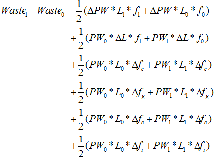

我们将最终使用引起的废水排放量的变化分配到四类最终使用：消费支出、资本形成、流出和流入。

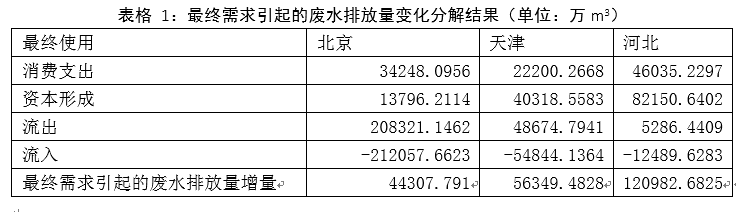

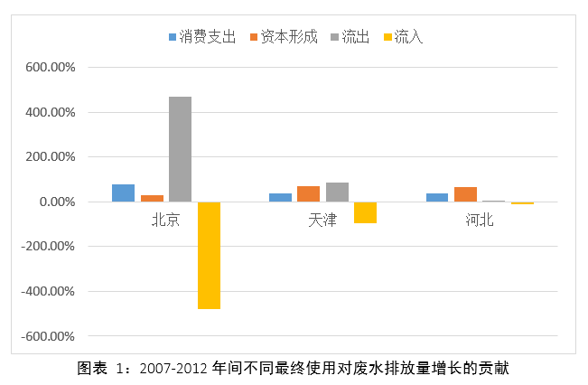

为了更深入地理解最终使用造成的废水排放量增长，我们从生产部门角度分解最终使用对废水排放量的增长作用。

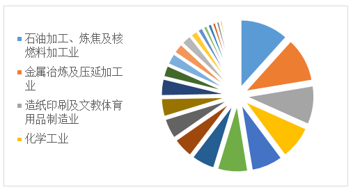

从图中可以看出，北京市流出推动的废水排放增量中，11.75%是由石油加工、炼焦及核燃料加工业推动的。紧接着是金属冶炼及压延加工业、造纸印刷及文教体育用品制造业和化学工，它们所占的比例分别为10.80%、9.40%和8.18%。

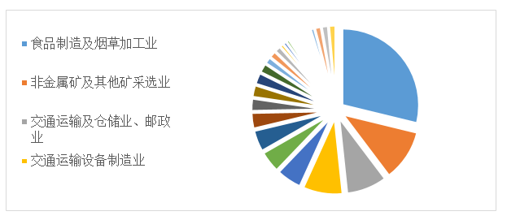

从图中可以看出，这些贡献最大的几个部门对流出推动的废水排放量贡献总量超过50%，其中食品制造及烟草加工业的贡献最大，站流出推动的废水排放量增量的33.66%；其次依次是非金属矿及其他矿采选业、交通运输及仓储业邮政业和交通运输设备制造业。

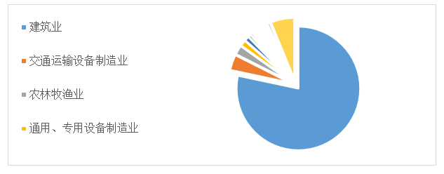

## 结论

- 2007年至2012年间，人均GDP的增长是推动京津冀地区废水排放量增长的最主要驱动因素，而废水直接排放系数的下降是京津冀地区废水排放量减少的最主要因素，它能够大幅度的抵消掉由于人均GDP提高带来的废水排放量的增长。
- 从最终使用的角度来看，流出对北京市和天津市2007年至2012年间废水排放增长的推动作用最大，而资本形成却对河北省2007年至2012年间废水排放增长的推动作用最大。
- 在最终需求推动的废水排放量增量中，石油加工、炼焦及核燃料加工业、食品制造及烟草加工业和建筑业的贡献最大。

[figure not shown]